# Introduction to R

### R as a calculating environment

모든 프로그래밍 언어가 그렇듯, R 또한 계산기로 사용할 수 있다. 다음의 산술 계산들을 살펴보라.

```r
5^2 # Same as 5**2.
```

```
## [1] 25
```

```r
(1 + 1 / 100) ^ 100
```

```
## [1] 2.704814
```

```r
17 %% 5
```

```
## [1] 2
```

```r
17 %/% 5
```

```
## [1] 3
```

위 출력에서 `[1]`은 계산 결과가 vector로서 vector의 첫 번째 아이템임을 뜻한다.

| symbol | meaning |
| --- | --- |
| + | 더하기 (addition) |
| - | 빼기 (subtraction) |
| * | 곱하기 (multiplication) |
| / | 나누기 (division) |
| ^ | 거듭제곱 (exponential) |
| %% | 나머지 (modulus) |
| %/% | 정수 나누기 (integer division) |

위 계산 기호를 이용하여 다양한 계산을 실습해 보라.

### Built-in function in R

R에서는 이미 만들어져 있는 built-in 함수들이 있어, 활용할 수 있다.  
우리가 잘 아는 많은 수학 함수들도 built-in 함수들로 구현되어 있다.  
`sin(x), cos(x), tan(x), exp(x), log(x), sqrt(x), floor(x), ceiling(x), round(x)`  
기본적인 함수 사용법은 함수 이름을 입력하고, 이 후의 괄호 안에 필요한 값을 전달하여 사용한다.  
함수에 대한 자세한 내용은 추후에 공부해 보기로 한다.

```r
exp(1)
```

```
## [1] 2.718282
```

```r
options(digits = 16) # 보여주는 소수점 자리 조정정
exp(1)
```

```
## [1] 2.718281828459045
```

```r
pi
```

```
## [1] 3.141592653589793
```

```r
sin(pi/6)
```

```
## [1] 0.4999999999999999
```

```r
sqrt(4)
```

```
## [1] 2
```

```r
floor(2.3)
```

```
## [1] 2
```

```r
ceiling(2.3)
```

```
## [1] 3
```

```r
round(2.3)
```

```
## [1] 2
```

```r
options(digits = 7)
```

### Variable

변수를 생성하여 값을 할당하고 이를 사용할 수 있다.

- 변수 할당을 위해 `<-` 명령을 사용한다.
  - 영어로는 “gets”라고 표현한다.
  - 다른 언어에서처럼 `=`을 이용할 수도 있다.
- 변수 이름은 영어 문자, 숫자, `.`, `_`를 이용하여 만든다.
  - 이름의 시작은 문자 혹은 `.`와 바로 문자를 이어서 만든다.
  - 이름은 대소문자 구분함.
  - 예: `x`, `y`, `my_variable`, `a1`, `a2`, `.important_variable`, `x.input`
  - 잘못된 예: `2016_income`, `.1grade`, `_x`, `y@gmail.com`

변수의 값을 출력하기 위해 변수 이름을 콘솔에 입력하여 엔터를 치면 된다.

아니면 `print`나 `show` 함수를 이용한다.

- 예: `print(x)` or `show(x)`.

```r
x <- 100  # assignment
x         # display
```

```
## [1] 100
```

```r
print(x)
```

```
## [1] 100
```

```r
show(x)
```

```
## [1] 100
```

```r
My.Weight <- 65; My.Height <- 1.75   # 한 줄에 여러 명령을 작성할 때 ;로 구분함
My.BMI <- My.Weight / My.Height^2
My.BMI
```

```
## [1] 21.22449
```

괄호를 사용하면 대입과 출력을 동시에 할 수 있다.

```r
(y <- (1 + 1 / x) ^ x)
```

```
## [1] 2.704814
```

대입 연산시, 우변이 먼저 계산되고 계산된 값이 좌변으로 전달된다.

```r
n <- 1
n <- n + 1
n
```

```
## [1] 2
```

다음의 명령문 또한 작동한다.

```r
3 -> three
three
```

```
## [1] 3
```

여러 대입을 한 번에 할 수도 있다.

```r
v <- w <- z <- 1
v
```

```
## [1] 1
```

```r
w
```

```
## [1] 1
```

```r
z
```

```
## [1] 1
```

### Functions

함수는 하나 혹은 여러 개의 입력을 인자(argument)로 받아 계산 결과 (return value)를 반환한다.

```r
seq(from = 1, to = 9, by = 2)
```

```
## [1] 1 3 5 7 9
```

```r
seq(from = 1, to = 9)
```

```
## [1] 1 2 3 4 5 6 7 8 9
```

내장된 도움말에 접근하려면 `help(function name)` 또는 `?function name`을 사용하라.

모든 함수에는 인자에 대한 기본 순서가 있다.

이 순서대로 인자들을 제공하면 이름을 지정할 필요가 없다.

반대로, 이름을 지정하여 인자들을 제공한다면 순서를 지킬 필요가 없다.

```r
seq(1, 9, 2)
```

```
## [1] 1 3 5 7 9
```

```r
seq(to = 9, from = 1)
```

```
## [1] 1 2 3 4 5 6 7 8 9
```

```r
seq(by = -2, 9, 1)
```

```
## [1] 9 7 5 3 1
```

More examples:

```r
seq(1, 5, 0.5)
```

```
## [1] 1.0 1.5 2.0 2.5 3.0 3.5 4.0 4.5 5.0
```

```r
seq(0.5, 0.1, -0.1)
```

```
## [1] 0.5 0.4 0.3 0.2 0.1
```

```r
seq(1, 10, 4)
```

```
## [1] 1 5 9
```

```r
x <- 9
seq(1, x, x/3)
```

```
## [1] 1 4 7
```

Chapter 4에서 함수에 대해 더 자세히 공부한다.

### Vectors

- 벡터(vector)는 R의 기본 데이터 구조이다.
  - 원자 벡터(atomic vector)라고도 불림
  - 인덱싱된 변수 집합
- 벡터 x의 i번째 요소는 x[i]로 표시됨
- 벡터의 모든 요소의 타입은 동일해야 함
  - 논리형(logical), 정수형(integer), 더블형(double, 종종 numeric이라고도 함), 문자형(character)
- 벡터를 생생성하는 세 가지 기본 함수
  - `seq` : 숫자의 일정한 간격을 갖는 시퀀스를 생성하는 함수
  - `rep` : 주어진 벡터의 요소를 반복하여 새로운 벡터를 생성하는 함수
  - `c` : 여러 요소를 하나의 벡터로 결합하는 함수
- 기본 세 가지 속성:
  - 타입, `typeof()`, 무슨 타입인지.
  - 길이, `length()`, 몇 개의 요소를 포함하는지.
  - 속성, `attributes()`, 추가적인 임의의 메타데이터.

```r
# short for sequence
(x <- seq(1, 20, by = 2))
```

```
##  [1]  1  3  5  7  9 11 13 15 17 19
```

```r
(x2 <- seq(1.1, 2, by = 0.1))
```

```
##  [1] 1.1 1.2 1.3 1.4 1.5 1.6 1.7 1.8 1.9 2.0
```

```r
# short for repeat
(y <- rep(3, 4))
```

```
## [1] 3 3 3 3
```

```r
# short for combine
(z <- c(y, x))
```

```
##  [1]  3  3  3  3  1  3  5  7  9 11 13 15 17 19
```

- another method for sequence

```r
(x <- 100:110)
```

```
##  [1] 100 101 102 103 104 105 106 107 108 109 110
```

```r
(y <- 110:100)
```

```
##  [1] 110 109 108 107 106 105 104 103 102 101 100
```

```r
length(x)  # 길이
```

```
## [1] 11
```

```r
sum(x)  # 합계계
```

```
## [1] 1155
```

- `letters, LETTERS`

```r
# the 26 lower-case letters of the Roman alphabet
letters
```

```
##  [1] "a" "b" "c" "d" "e" "f" "g" "h" "i" "j" "k" "l" "m" "n" "o" "p" "q" "r" "s"
## [20] "t" "u" "v" "w" "x" "y" "z"
```

```r
# the 26 upper-case letters of the Roman alphabet;
LETTERS
```

```
##  [1] "A" "B" "C" "D" "E" "F" "G" "H" "I" "J" "K" "L" "M" "N" "O" "P" "Q" "R" "S"
## [20] "T" "U" "V" "W" "X" "Y" "Z"
```

- `seq_along()`

`seq_along(x)` 는 `1:length(x)`와 같다.

```r
x <- letters[1:5]  # a b c d e
y <- seq_along(x)
print(y)
```

```
## [1] 1 2 3 4 5
```

- vector and index

```r
(x <- 100:110)
```

```
##  [1] 100 101 102 103 104 105 106 107 108 109 110
```

```r
# second element
x[2]
```

```
## [1] 101
```

```r
# last element
x[length(x)]
```

```
## [1] 110
```

```r
i <- c(1, 3, 2)

x[i]
```

```
## [1] 100 102 101
```

```r
x[1:5]
```

```
## [1] 100 101 102 103 104
```

minus index:

```r
j <- c(-1, -2, -3)
x[j]
```

```
## [1] 103 104 105 106 107 108 109 110
```

하지만 양수 인덱스와 음수 인덱스를 혼합할 수는 없으며, 다음 코드는 오류가 발생

```r
x[c(-1, 2)]
```

empty vector:

```r
x <- c()
```

원소별 연산:

```r
x <- c(1, 2, 3)
y <- c(4, 5, 6)
x * y
```

```
## [1]  4 10 18
```

```r
y ^ x
```

```
## [1]   4  25 216
```

길이가 같지 않은 벡터끼리의 연산

```r
c(1, 2, 3, 4) + c(1, 2)
```

```
## [1] 2 4 4 6
```

```r
2 * c(1, 2, 3)
```

```
## [1] 2 4 6
```

```r
(1:3)^2
```

```
## [1] 1 4 9
```

다음은 작동하나 경고 발생

```r
c(1, 2, 3) + c(1, 2)
```

벡터를 입력으로 받는 함수들

```r
sqrt(1:3)
```

```
## [1] 1.000000 1.414214 1.732051
```

```r
mean(1:6)
```

```
## [1] 3.5
```

```r
sort(c(5, 1, 3, 4, 2))
```

```
## [1] 1 2 3 4 5
```

논리 벡터

```r
logi <- c(TRUE, FALSE, T, F)
typeof(logi)
```

```
## [1] "logical"
```

문자 벡터

```r
char <- c("a", "vector", "of", "characters")
typeof(char)
```

```
## [1] "character"
```

정수 벡터

```r
integ <- c(1L, 2L, 3L, 4L)
typeof(integ)
```

```
## [1] "integer"
```

실수 벡터

```r
doub <- c(1, 2, 3, 4)
typeof(doub)
```

```
## [1] "double"
```

실수 벡터를 문자 벡터로로

```r
as.character(doub)
```

```
## [1] "1" "2" "3" "4"
```

문자 벡터를 실수 벡터로

```r
as.numeric(c("1.2", "3", "-0.001"))
```

```
## [1]  1.200  3.000 -0.001
```

정수 벡터로 변환

```r
as.integer(c("23.2", "-2.001"))
```

```
## [1] 23 -2
```

#### `typeof()`

`typeof()`는 (내부) 객체 타입을 반환한다.

- logical - logical vector
- double - double vector
- integer - integer vector
- character - character vector
- list - see Ch.5
- builtin : R built-in function
- closure : user defined function
- and so on.

간단히 말해, R의 객체는 C 언어를 통해 구현되며, 내부 타입은 C 수준의 데이터 타입을 의미한다.

#### Coercion

벡터에서 서로 다른 유형의 요소를 결합하려고 하면, 이 요소들은 가장 유연한 유형으로 강제 변환된다.

다음에서 오른쪽으로 갈수록 더 유연한 유형이다.

- logical, integer, double, character

```r
c("a", 1)
```

```
## [1] "a" "1"
```

```r
c(TRUE, FALSE, 0)
```

```
## [1] 1 0 0
```

#### Example : mean and variance

직접 계산한 평균과 분산을 내장 함수의 결과와 비교해 보자.

- `mean()` : 평균을 계산하는 built-in 함수
- `var()` : 분산을 계산하는 built-in 함수

```r
x <- c(1.2, 0.9, 0.8, 1, 1.2)

x.mean <- sum(x)/length(x)

x.mean - mean(x)
```

```
## [1] 0
```

```r
x.var <- sum((x-x.mean)^2)/(length(x)-1)
x.var - var(x)
```

```
## [1] 0
```

#### Example : simple numerical integration

수치적분의 기본 문제는 정적분에 대한 근사 해를 계산하는 것이다.

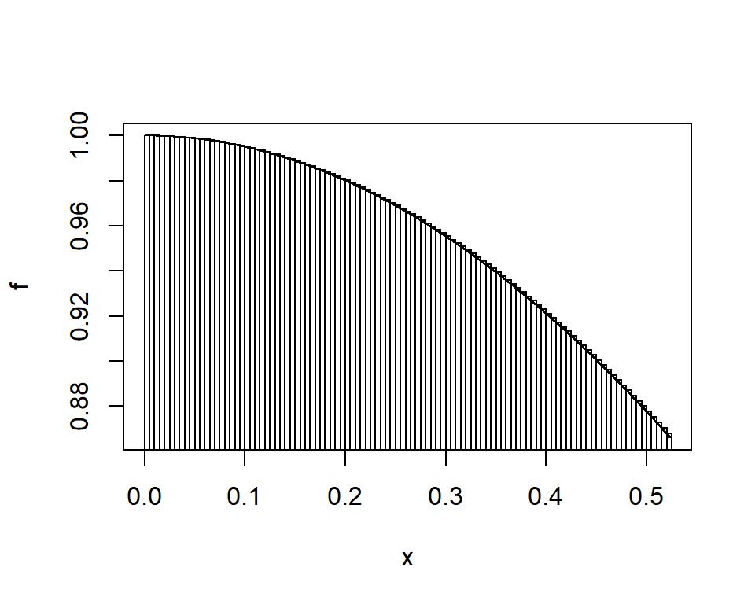

```r
dt <- 0.005
t <- seq(0, pi/6, by = dt)
ft <- cos(t)
(I <- sum(ft) * dt)  # 적분의 근사값
```

```
## [1] 0.5015487
```

`t`가 벡터이며 `ft` 또한 벡터가 된다.

`sin(pi/6)`가 적분의 실제값이므로 아래 값이 0에 가까울수록 좋은 근사이다.

```r
I - sin(pi/6)
```

```
## [1] 0.001548651
```

#### Example : exponential limit

$e$의 근사값 수열을 계산하여 극한을 살펴보자.

$$e = \lim_{n \to \infty} \left( 1 +
\frac{1}{n} \right)^n$$

```r
n <- seq(10, 200, by = 10)

y <- (1 + 1/n)^n

exp(1) - y
```

```
##  [1] 0.124539368 0.064984123 0.043963053 0.033217990 0.026693799 0.022311689
##  [7] 0.019165457 0.016796888 0.014949367 0.013467999 0.012253747 0.011240338
## [13] 0.010381747 0.009645015 0.009005917 0.008446252 0.007952077 0.007512533
## [19] 0.007119034 0.006764706
```

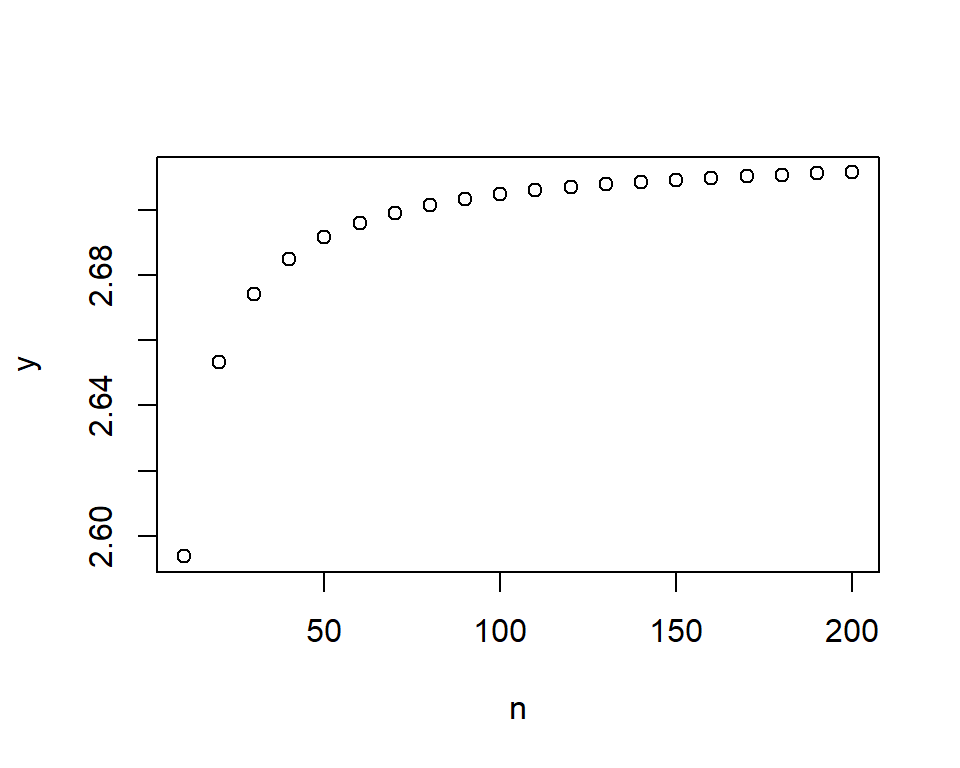

```r
plot(n, y)
```

### Missing data

R에서 결측 데이터는 `NA`로 표현된다.

- `is.na`는 R 객체의 요소들이 결측값(NA)인지 여부를 논리값으로 반환한다.

```r
a <- NA   # assign NA to variable A
is.na(a)     # is it missing?
```

```
## [1] TRUE
```

```r
a <- c(11, NA, 13)
is.na(a)
```

```
## [1] FALSE  TRUE FALSE
```

```r
mean(a)
```

```
## [1] NA
```

```r
mean(a, na.rm = TRUE) #NAs can be removed
```

```
## [1] 12
```

`NA`는 logical 데이터로 설정되지만,

```r
typeof(NA)
```

```
## [1] "logical"
```

numeric, integer, charactor로 상황에 따라 강제 변환될 수 있다.

```r
x <- c(NA, 10)
typeof(x[1])
```

```
## [1] "double"
```

```r
y <- c(NA, "abc")
typeof(y[1])
```

```
## [1] "character"
```

### Inf and -Inf

계산 결과가 너무 크면, R은 `Inf`를 반환한다.

```r
2 ^ 1024
```

```
## [1] Inf
```

```r
- 2 ^ 1024
```

```
## [1] -Inf
```

```r
1 / 0
```

```
## [1] Inf
```

### NaN

계산 결과가 의미가 없으면, R은 숫자가 아님을 나타내는 `NaN`을 반환한다.

```r
Inf - Inf
```

```
## [1] NaN
```

```r
0 / 0
```

```
## [1] NaN
```

### Expression and assignment

표현식(expression)은 실행 가능한 코드 구문을 의미한다.

```r
seq(10, 20, by=3)
```

```
## [1] 10 13 16 19
```

```r
4
```

```
## [1] 4
```

```r
mean(c(1,2,3))
```

```
## [1] 2
```

```r
1 > 2
```

```
## [1] FALSE
```

표현식의 계산 결과를 `<-`를 사용하여 저장하면, 이를 할당이라고 한다.

```r
x1 <- seq(10, 20, by=3)
```

```r
x2 <- 1>2
```

논리 표현식은 다음을 사용하여 형성된다.

- 비교 연산자
  - `<`, `>`, `<=`, `>=`, `==`, `!=` (같지 않다)
- 논리 연산자
  - `&` (and), `|` (or), `!` (not)
- 논리 표현식의 값은 `TRUE` 또는 `FALSE`이다.
  - 정수 `1`과 `0`도 `TRUE` 또는 `FALSE`로 사용할 수 있다.

```r
c(0, 0, 1, 1) | c(0, 1, 0, 1)
```

```
## [1] FALSE  TRUE  TRUE  TRUE
```

#### Example : rounding error

많은 소수점 숫자는 컴퓨터에서 반올림 오류가 발생한다.

```r
2 * 2 == 4
```

```
## [1] TRUE
```

```r
sqrt(2) * sqrt(2) == 2
```

```
## [1] FALSE
```

해결책은 `all.equal(x, y)`를 사용하는 것으로, `x`와 `y`의 차이가 특정 허용 오차보다 작으면 TRUE를 반환한다.

```r
all.equal(sqrt(2) * sqrt(2), 2)
```

```
## [1] TRUE
```

### Subsetting

R의 subsetting 연산자는 강력하고 빠르다.

subsetting 연산은 처음에는 배우기 어려울 수 있지만, 익히면 편리하다.

TRUE/FALSE 벡터를 사용하여 부분 벡터를 추출할 수 있다.

`x[subset]`

- `x`: 벡터, 리스트, 데이터 프레임 등에서 요소를 추출하려는 객체이다.
- `subset`: 선택할 요소의 인덱스 값을 지정하는 벡터, 논리 벡터, 또는 조건식이다.

```r
vec <- c("a", "b", "c", "d", "e")
sub_vec <- vec[c(1, 3, 5)]
print(sub_vec)  # 출력: "a" "c" "e"
```

```
## [1] "a" "c" "e"
```

```r
vec <- c(10, 20, 30, 40, 50)
sub_vec <- vec[c(TRUE, FALSE, TRUE, FALSE, TRUE)]
print(sub_vec)  # 출력: 10 30 50
```

```
## [1] 10 30 50
```

```r
x <- 1:10
x %% 4 == 0
```

```
##  [1] FALSE FALSE FALSE  TRUE FALSE FALSE FALSE  TRUE FALSE FALSE
```

```r
( y <- x[ x %% 4 == 0 ] )
```

```
## [1] 4 8
```

R은 또한 `subset()` 함수를 제공하며, 이는 `NA`를 무시한다.

- 반면에 `x[subset]`형태의 expression은 `NA`를 유지한다.

```r
x <- c(1, NA, 3, 4)
x[x > 2]
```

```
## [1] NA  3  4
```

```r
subset(x, subset = x > 2 )
```

```
## [1] 3 4
```

TRUE 요소의 인덱스 위치를 얻으려면 `which(v)`를 사용한다.

- 여기서 `v`는 TRUE/FALSE로 표현되는 논리 벡터.

```r
x <- c(1, 1, 2, 3, 5, 8, 13)
which(x %% 2 == 0)
```

```
## [1] 3 6
```

더 많은 subsetting 예제들:

```r
x <- c(2.1, 4.2, 3.3, 5.4)
```

```r
x[c(TRUE,FALSE,TRUE,FALSE)]
```

```
## [1] 2.1 3.3
```

```r
x[x > 3]
```

```
## [1] 4.2 3.3 5.4
```

```r
x[order(x)]
```

```
## [1] 2.1 3.3 4.2 5.4
```

### Sequential `&&` and `||`

`x && y`를 계산할 때, R은 먼저 `x`를 계산한다.

- 만약 `x`가 FALSE라면, R은 `y`를 평가하지 않고 즉시 FALSE를 반환한다.

`x || y`를 평가할 때, R은 먼저 `x`를 평가한다.

- 만약 `x`가 TRUE라면, R은 `y`를 평가하지 않고 즉시 TRUE를 반환한다.

즉, 불필요한 평가를 피하기 위해 첫 번째 조건이 결과를 결정할 수 있을 때 두 번째 조건을 평가하지 않는 방식이다.

이렇게 `x`와 `y`를 순차적으로 평가하는 방식은 `y`가 정의되지 않을 수도 있을 때 유용하다.

```r
x <- 0
sin(1/x)  # NaN
```

```
## Warning in sin(1/x): NaN이 생성되었습니다
```

```
## [1] NaN
```

```r
x == 0 || sin(1/x) == 0
```

```
## [1] TRUE
```

아래에서는 `|`를 사용했기 때문에 `sin(1/x)`도 계산되며, 경고가 발생한다.

```r
x == 0 | sin(1/x) == 0
```

```
## Warning in sin(1/x): NaN이 생성되었습니다
```

```
## [1] TRUE
```

`&&` 및 `||` 연산자는 스칼라에 대해서만 작동하는 반면, `&` 및 `|` 연산자는 벡터의 각 요소에 대해 요소별로 작동한다.

```r
c(TRUE, FALSE) & c(TRUE, TRUE)
```

```
## [1]  TRUE FALSE
```

```r
# 에러 발생
c(TRUE, FALSE) && c(TRUE, TRUE)
```

### subsetting and assignment

Subsetting셋 연산자는 할당 연산자와 결합하여 사용할 수 있다. 이를 통해 특정 요소를 선택하여 값을 변경하거나 업데이트할 수 있다.

```r
x <- 1:5
x[c(1, 2)] <- 2:3
x
```

```
## [1] 2 3 3 4 5
```

```r
x[-1] <- 4:1
x
```

```
## [1] 2 4 3 2 1
```

```r
x[x %% 2 == 0] <- 0
x
```

```
## [1] 0 0 3 0 1
```

```r
x[which(x == max(x))] <- 100
x
```

```
## [1]   0   0 100   0   1
```

### Names

벡터의 각 요소들에 이름을 지정할 수 있다.

```r
(x <- c(a = 1, b = 2, c = 3))
```

```
## a b c
## 1 2 3
```

`names` 함수는 character 벡터로 이름들을 반환한다.

```r
names(x)
```

```
## [1] "a" "b" "c"
```

`names` 함수로 원소들의 이름을 지정할 수도 있다.

```r
y <- 1:3
names(y) <- c("first", "second", "third")
y
```

```
##  first second  third
##      1      2      3
```

이름을 통해 원소를 선택할 수 있다.

```r
y["first"]
```

```
## first
##     1
```

```r
y[c("first", "third")]
```

```
## first third
##     1     3
```

### Matrix

행렬은 벡터로부터 `matrix` 함수를 사용하여 생성할 수 있다:

- `matrix(data, nrow = 1, ncol = 1, byrow = FALSE)`
  - `data`: 최대 `nrow*ncol` 길이의 벡터
  - 벡터의 길이가 `nrow*ncol`보다 작으면 데이터가 필요한 만큼 재사용된다.
  - `nrow`: 행의 수
  - `ncol`: 열의 수
  - `byrow = TRUE`: 행 단위로 행렬을 채운다.
  - `byrow = FALSE`: 열 단위로 행렬을 채운다. 기본값이다.
- `diag(x)`: 대각 행렬을 생성한다.
- `rbind(...)` : 같은 길이의 행을 가진 행렬들을 행 기준으로 결합한다.
- `cbind(...)` : 같은 길이의 열을 가진 행렬들을 열 기준으로 결합한다.

이러한 함수들을 통해 R에서 행렬을 생성하고 조작할 수 있다.

Example:

```r
(A <- matrix(1:6, nrow = 2, ncol = 3))
```

```
##      [,1] [,2] [,3]
## [1,]    1    3    5
## [2,]    2    4    6
```

```r
(A <- matrix(1:6, nrow = 2, ncol = 3, byrow = TRUE))
```

```
##      [,1] [,2] [,3]
## [1,]    1    2    3
## [2,]    4    5    6
```

행렬의 원소를 선택할 때, `[ , ]`를 이용하며, `,`를 기준으로 왼쪽은 행, 오른쪽은 열을 의미

```r
A[1, 3] <- 0  # 행 번호 1, 열 번호 3
A
```

```
##      [,1] [,2] [,3]
## [1,]    1    2    0
## [2,]    4    5    6
```

```r
# 모든 행과 2번째부터 3번째까지의 열을 선택
A[, 2:3]
```

```
##      [,1] [,2]
## [1,]    2    0
## [2,]    5    6
```

대각 행렬

```r
(B <- diag(c(1, 2, 3)))
```

```
##      [,1] [,2] [,3]
## [1,]    1    0    0
## [2,]    0    2    0
## [3,]    0    0    3
```

유용한 행렬 연산

- 일반적인 대수 연산, 예를 들어 `*`, `+`, `-`, `/` 등은은 요소별로 작동한다.
- 행렬곱 연산을 수행하기 위해서는 `%*%`를 사용한다.
- `nrow(x)`: 행의 개수를 반환
- `ncol(x)`: 열의 개수를 반환
- `det(x)`: 행렬 `x`의 행렬식을 계산
- `t(x)`: 행렬 `x`의 전치 행렬을 반환
- `solve(A, B)`: `A %*% x = B`를 만족하는 `x`를 반환
- `A`가 가역 행렬일 경우, `solve(A)`는 `A`의 역행렬을 반환한다.

```r
A <- matrix(c(3, 5, 2, 3), nrow=2, ncol=2)
B <- matrix(c(1, 1, 0, 1), nrow=2, ncol=2)
```

```r
A %*% B
```

```
##      [,1] [,2]
## [1,]    5    2
## [2,]    8    3
```

```r
A.inv <- solve(A)
A %*% A.inv   # we observe rounding error
```

```
##      [,1]          [,2]
## [1,]    1 -8.881784e-16
## [2,]    0  1.000000e+00
```

```r
A^(-1)   #This is not an inverse. ^(-1) applies elementwise.
```

```
##           [,1]      [,2]
## [1,] 0.3333333 0.5000000
## [2,] 0.2000000 0.3333333
```

`cbind()` : R 객체들을 열 단위로 결합

`rbind()` : R 객체들을 행 단위로 결합

```r
(M <- cbind(A,B))
```

```
##      [,1] [,2] [,3] [,4]
## [1,]    3    2    1    0
## [2,]    5    3    1    1
```

```r
(N <- rbind(A,B))
```

```
##      [,1] [,2]
## [1,]    3    2
## [2,]    5    3
## [3,]    1    0
## [4,]    1    1
```

행과 열의 이름을 지정할 수 있다.

```r
colnames(M) <- c("a", "b", "c", "d")
M
```

```
##      a b c d
## [1,] 3 2 1 0
## [2,] 5 3 1 1
```

```r
rownames(M) <- c("first", "second")
M
```

```
##        a b c d
## first  3 2 1 0
## second 5 3 1 1
```

```r
# number of rows
nrow(M)
```

```
## [1] 2
```

```r
# number of columns
ncol(M)
```

```
## [1] 4
```

#### Subsetting of matrix

열의 선택:

```r
(partM1 <- M[, c(1, 2)])
```

```
##        a b
## first  3 2
## second 5 3
```

열을 이름을 이용하여 선택:

```r
(partM1 <- M[, c("a", "b")])
```

```
##        a b
## first  3 2
## second 5 3
```

`partM1`는 matrix이다.

- `class`는 객체의 클래스를 확인하거나 설정하는 데 사용된다.

```r
class(partM1)
```

```
## [1] "matrix" "array"
```

Matrix에서서 하나의 열을 선택할 때, 결과는 행렬이 아닌 벡터가 된다.

```r
this_is_vector_now <- M[, "a"]
class(this_is_vector_now)
```

```
## [1] "numeric"
```

Matrix 클래스를 유지하고 싶다면 `drop = FALSE`를 이용한다.

```r
still_matrix <- M[, "a", drop = FALSE]
class(still_matrix)
```

```
## [1] "matrix" "array"
```

행의 선택

```r
(partM2 <- M[1,])
```

```
## a b c d
## 3 2 1 0
```

다음은 행과 열을 모두 선택한다.

```r
(partM2 <- M[1, c(2, 3)])
```

```
## b c
## 2 1
```

```r
class(partM2)
```

```
## [1] "numeric"
```

R에서 행렬열에 단일 인덱스를 사용할 경우, R은 인덱스를 열 기준으로 세어 나간다. 즉, 첫 번째 열의 모든 요소를 먼저 세고, 다음 열로 넘어가서 다시 세는 방식이다.

```r
M[1]
```

```
## [1] 3
```

```r
M[2]
```

```
## [1] 5
```

```r
M[3]
```

```
## [1] 2
```

```r
M[4]
```

```
## [1] 3
```

```r
is.vector(partM2)
```

```
## [1] TRUE
```

```r
is.matrix(partM2)
```

```
## [1] FALSE
```

```r
(Mm <- as.matrix(partM2))
```

```
##   [,1]
## b    2
## c    1
```

```r
class(Mm)
```

```
## [1] "matrix" "array"
```

```r
(Mv <- as.vector(Mm))
```

```
## [1] 2 1
```

```r
class(Mv)
```

```
## [1] "numeric"
```

### Objects and classes

R은 객체 지향 언어이며, R의 모든 객체는 어떤 클래스의 멤버이다.

`class` 함수를 사용해서 객체의 클래스를 확인할 수 있다.

```r
# numeric vector
class(c(1, 2, 3))
```

```
## [1] "numeric"
```

```r
# character vector
class(c("c", "B", "z"))
```

```
## [1] "character"
```

```r
# function
class(sin)
```

```
## [1] "function"
```

```r
class(matrix(c(1,2)))
```

```
## [1] "matrix" "array"
```

### Workspace

R에서 생성한 객체는 명시적으로 삭제할 때까지 존재한다.

- `rm(x)` : 객체 `x`를 삭제
- `rm(list=ls())` : 모든 객체를 삭제

### Working directory

R을 실행할 때, R은 드라이브의 디렉토리 중 하나를 작업 디렉토리로 사용한다.  
- 기본적으로 이 디렉토리에서 사용자 작성 프로그램과 데이터 파일을 찾는다.  
작업 디렉토리를 확인하려면, 다음 명령어를 사용한다:

```r
getwd()
```

작업 디렉토리를 “dir”로 변경하려면 다음 명령어를 사용한다: - 여기서 “dir”은 변경하고자 하는 디렉토리의 경로를 의미한다. 경로를 지정할 때는 시스템에 맞는 경로 형식을 사용해야 한다.

```r
setwd("dir")
```

`/`를 이용하여 디렉토리 및 파일 경로를 나타내며, `.`는 현재 디렉토리를, `..`는 상위 디렉토리를 나타낸다.

### Writing script

R 프롬프트에서 모든 가능한 R 표현식을 입력하고 실행할 수 있지만, 스크립트를 작성하는 것이 훨씬 더 편리하다.

- 스크립트는 단순히 R 표현식의 모음으로 구성된다.
- 프로그램 및 코드라는 용어를 스크립트와 동일하게 사용한다.
- Rgui나 Rstudio의 내장 편집기를 사용할 수 있다.

### Help

R 명령어나 함수 `x`에 대해 더 알고 싶다면 `help(x)` 또는 `?x`를 입력할 수 있다.

정확한 이름이 기억나지 않는다면, `help.search("x")`를 사용할 수 있다.

HTML 도움말 명령어: `help.start()`

### package

R은 다양한 유용한 패키지를 제공한다.

https://cran.r-project.org/web/packages/

패키지를 설치하려면 다음 명령어를 사용한다:

`install.packages("packagename")`

또는 패키지 메뉴를 사용할 수 있다.

패키지를 사용하려면 다음과 같이 접근한다:

`library("packagename")`

R 문서: https://www.rdocumentation.org/

### 유용한 built-in 수학 함수들

| R 함수 | 설명 | 예제 | 결과 |
| --- | --- | --- | --- |
| `x%%y` | x를 y로 나눈 나머지 | `10%%3` | `1` |
| `ceiling()` | x보다 크거나 같은 최소 정수 | `ceiling(2.3)` | `3` |
| `floor()` | x보다 작거나 같은 최대 정수 | `floor(2.3)` | `2` |
| `round()` | 첫 번째 인수를 두 번째 인수로 지정된 자릿수로 반올림 | `round(2.375,2)` | `2.38` |
| `signif()` | 주어진 유효 자릿수로 첫 번째 인수를 반올림 | `signif(2.375,2)` | `2.4` |
| `trunc()` | 소수점 이하를 제거한 x의 정수 부분 | `trunc(1.37)` | `1` |
| `sign()` | 부호 (1 또는 -1) | `sign(-2)` | `-1` |
| `abs()` | 절대값 | `abs(-2)` | `2` |
| `exp()` | 지수 함수 e^x | `exp(0)` | `1` |
| `log()` | 자연 로그 | `log(1)` | `0` |
| `sqrt()` | 제곱근 | `sqrt(4)` | `2` |
| `range()` | 범위 | `range(2,5,1)` | `1 5` |
| `max()` | 최대값 | `max(2,3)` | `3` |
| `min()` | 최소값 | `min(2,3)` | `2` |
| `sum()` | 인수들의 합 | `sum(2,3,4)` | `9` |
| `prod()` | 인수들의 곱 | `prod(2,4,2)` | `16` |
| `cummax()` | 누적 최대값 | `cummax(c(2,4,3))` | `2 4 4` |
| `cummin()` | 누적 최소값 | `cummin(c(2,4,1))` | `2 2 1` |
| `cumsum()` | 누적 합 | `cumsum(c(2,3,4))` | `2 5 9` |
| `cumprod()` | 누적 곱 | `cumprod(c(2,4,3))` | `2 8 24` |
| `cos()` | 코사인 | `cos(pi)` | `-1` |
| `sin()` | 사인 | `sin(pi/2)` | `1` |
| `tan()` | 탄젠트 | `tan(pi/4)` | `1` |
| `acos()` | 아크코사인 | `acos(1)` | `0` |
| `asin()` | 아크사인 | `asin(0)` | `0` |
| `atan()` | 아크탄젠트 | `atan(0)` | `0` |
| `cosh()` | 쌍곡 코사인 | `cosh(0)` | `1` |
| `sinh()` | 쌍곡 사인 | `sinh(0)` | `0` |
| `tanh()` | 쌍곡 탄젠트 | `tanh(0)` | `0` |
| `acosh()` | 역쌍곡 코사인 | `acosh(1)` | `0` |
| `asinh()` | 역쌍곡 사인 | `asinh(0)` | `0` |
| `atanh()` | 역쌍곡 탄젠트 | `atanh(0)` | `0` |
| `beta()` | 베타 함수 | `beta(1,2)` | `0.5` |
| `lbeta()` | 베타 함수의 로그 | `lbeta(1,1)` | `0` |
| `factorial()` | 팩토리얼 | `factorial(6)` | `720` |
| `choose()` | 이항 계수 | `choose(5,2)` | `10` |
| `gamma()` | 감마 함수 | `gamma(4)` | `6` |
| `lgamma()` | 감마 함수의 로그 | `lgamma(2)` | `0` |
| `digamma()` | 감마 함수의 1차 미분 | `digamma(2)` | `0.4227843` |
| `trigamma()` | 감마 함수의 2차 미분 | `trigamma(2)` | `0.6449341` |